# Actividad 5. Árboles Binomiales del Portafolio (AAPL, JPM, NVDA, TSLA, XOM)

Tania Manuela López Suárez | Ricardo Terrazas Duque | Mauricio Martínez

2026-10-27

> Adaptación de la práctica *Opciones y Árboles Binomiales (Lab1)* al portafolio de la Actividad 3: **AAPL, JPM, NVDA, TSLA y XOM**. Se conserva la metodología original (media-varianza, MGB, VaR y árboles binomiales). La tasa libre de riesgo es la del T-Bill 07-ene-2027 (4.16 %) usada en la Actividad 3 y la fecha de valuación es el 12-oct-2026 (misma que la Actividad 3). La sección 12.1 agrega árboles binomiales de 1 y 2 pasos para las **Calls americanas con vencimiento de 52 días** operadas en Investopedia, y la sección 13 incluye la evidencia de **TradingView, CME e Investopedia**. Requiere conexión a internet (`tq_get` descarga precios de Yahoo Finance).

# 1. Parámetros generales

```r
tick <- c("AAPL", "JPM", "NVDA", "TSLA", "XOM")  # en orden alfabético, igual que las columnas de log_ret_xts
start <- as.Date("2023-10-01")
end <- as.Date("2026-10-13")  # tq_get excluye la fecha final: datos hasta el 12-oct-2026
```

**Interpretación:** Se definen los símbolos de las acciones a analizar y el rango de tiempo para obtener los datos históricos.

# 2. Carga de precios históricos (2023-10-01 a 2026-10-12)

```r
price_data <- tq_get(tick, from = start, to = end, get = "stock.prices")

log_ret_tidy <- price_data %>%
  group_by(symbol) %>%
  tq_transmute(select = adjusted, mutate_fun = periodReturn,
               period = "daily", col_rename = "ret", type = "log")

log_ret_xts <- log_ret_tidy %>% spread(symbol, value = ret) %>% tk_xts()
```

```r
#Precios históricos
price_data
```

| symbol | date | open | high | low | close | volume | adjusted |
| --- | --- | --- | --- | --- | --- | --- | --- |
| AAPL | 2023-10-02 | 171.220 | 174.300 | 170.930 | 173.750 | 52164500 | 171.43135 |
| AAPL | 2023-10-03 | 172.260 | 173.630 | 170.820 | 172.400 | 49594600 | 170.09938 |
| AAPL | 2023-10-04 | 171.090 | 174.210 | 170.970 | 173.660 | 53020300 | 171.34259 |
| AAPL | 2023-10-05 | 173.790 | 175.450 | 172.680 | 174.910 | 48527900 | 172.57591 |
| AAPL | 2023-10-06 | 173.800 | 177.990 | 173.180 | 177.490 | 57266700 | 175.12148 |
| AAPL | 2023-10-09 | 176.810 | 179.050 | 175.800 | 178.990 | 42390800 | 176.60143 |
| AAPL | 2023-10-10 | 178.100 | 179.720 | 177.950 | 178.390 | 43698000 | 176.00946 |
| AAPL | 2023-10-11 | 178.200 | 179.850 | 177.600 | 179.800 | 47551100 | 177.40063 |
| AAPL | 2023-10-12 | 180.070 | 182.340 | 179.040 | 180.710 | 56743100 | 178.29852 |
| AAPL | 2023-10-13 | 181.420 | 181.930 | 178.140 | 178.850 | 51427100 | 176.46333 |

[output cut: 3790 more lines]

```r
#Retornos logaritmicos
log_ret_xts
```

```
##                    AAPL          JPM         NVDA         TSLA           XOM
## 2023-10-02  0.000000000  0.000000000  0.000000000  0.000000000  0.000000e+00
## 2023-10-03 -0.007800042 -0.007400252 -0.028654457 -0.020356864  1.728149e-03
## 2023-10-04  0.007282147  0.004474786  0.011969139  0.057649575 -3.809897e-02
## 2023-10-05  0.007172207  0.004207266  0.014584153 -0.004259387 -2.276848e-02
## 2023-10-06  0.014642665  0.015278329  0.023749016  0.001844140 -1.683971e-02
## 2023-10-09  0.008415481 -0.002276798 -0.010743417 -0.003306367  3.439282e-02
## 2023-10-10 -0.003357612  0.006060016  0.011529780  0.015097008 -4.246422e-03
## 2023-10-11  0.007872902  0.003426994  0.021770787 -0.002392682 -3.651166e-02
## 2023-10-12  0.005048593 -0.002328895  0.002965425 -0.015789985 -1.879540e-04
## 2023-10-13 -0.010346130  0.014907670 -0.032121948 -0.030395093  3.143462e-02
##        ...
## 2026-09-29 -0.026955810 -0.004794690 -0.007235736 -0.012980840 -7.225141e-03
## 2026-09-30  0.010929716 -0.012466260  0.005136200  0.005567742  8.639325e-03
## 2026-10-01 -0.008140611  0.007078279  0.010800539 -0.001974870  6.553028e-03
## 2026-10-02  0.010150522 -0.002403967  0.013295935  0.045488762  1.159059e-03
## 2026-10-05 -0.002400277  0.000000000  0.020937625  0.021727259 -6.094026e-05
## 2026-10-06  0.002220460  0.001661570  0.001422226  0.005135529  2.922528e-03
## 2026-10-07  0.009070653 -0.005144860 -0.007425950 -0.007567691 -2.617678e-03
## 2026-10-08  0.011076927  0.005567418 -0.029877233 -0.007465391  2.676447e-02
## 2026-10-09 -0.011166035  0.004725936 -0.005220113  0.020325398  2.607887e-03
## 2026-10-12  0.012780347  0.003926327 -0.012993999 -0.012277870  1.882252e-02
```

**Interpretación:** Se descargan los precios ajustados y se calculan los retornos logarítmicos diarios para cada acción.

# 3. Visualización de retornos

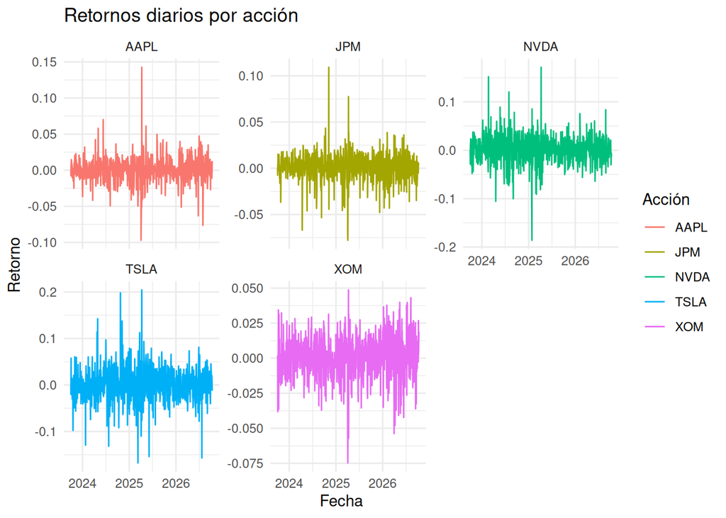

```r
ret_long <- log_ret_tidy %>% rename(Date = date, Acción = symbol, Retornos = ret)

ggplot(ret_long, aes(x = Date, y = Retornos, color = Acción)) +
  geom_line() +
  facet_wrap(~Acción, scales = "free_y") +
  labs(title = "Retornos diarios por acción", x = "Fecha", y = "Retorno") +
  theme_minimal()
```

**Interpretación:** Se visualizan los retornos diarios por acción, lo cual permite evidenciar su volatilidad y comportamiento temporal.

# 4. Portafolio de media varianza

```r
cov_mat <- cov(log_ret_xts) * 252
mean_ret <- colMeans(log_ret_xts)

set.seed(123)
num_port <- 5000
all_wts <- matrix(nrow = num_port, ncol = length(tick))
port_returns <- port_risk <- sharpe_ratio <- numeric(num_port)

for (i in 1:num_port) {
  wts <- runif(length(tick)); wts <- wts / sum(wts)
  all_wts[i, ] <- wts
  port_ret <- sum(wts * mean_ret)
  port_returns[i] <- (port_ret + 1)^252 - 1
  port_sd <- sqrt(t(wts) %*% (cov_mat %*% wts))
  port_risk[i] <- port_sd
  sharpe_ratio[i] <- port_returns[i] / port_sd
}

portfolio_values <- tibble(Return = port_returns, Risk = port_risk, SharpeRatio = sharpe_ratio)
colnames(all_wts) <- tick
portfolio_values <- bind_cols(as_tibble(all_wts), portfolio_values)
media_var <- portfolio_values[which.min(portfolio_values$Risk), ]
weights_media <- as.numeric(media_var[, tick])
names(weights_media) <- tick
cov_mat
```

```
##             AAPL        JPM        NVDA        TSLA          XOM
## AAPL 0.070767941 0.01685284  0.03642647 0.057285728  0.006593589
## JPM  0.016852839 0.05293805  0.02591186 0.040798498  0.010332625
## NVDA 0.036426473 0.02591186  0.21657860 0.100497041 -0.005099070
## TSLA 0.057285728 0.04079850  0.10049704 0.330933476  0.002755576
## XOM  0.006593589 0.01033262 -0.00509907 0.002755576  0.055035821
```

```r
media_var
```

| AAPL | JPM | NVDA | TSLA | XOM | Return | Risk | SharpeRatio |
| --- | --- | --- | --- | --- | --- | --- | --- |
| 0.2506721 | 0.3361882 | 0.06179165 | 0.009496019 | 0.341852 | 0.2837984 | 0.1634704 | 1.736084 |

**Interpretación:** Se optimiza un portafolio de mínima varianza generando múltiples combinaciones de pesos y se elige aquella con menor riesgo.

# 5. Distribución de $1 millón de dólares

```r
investment <- 1e6
latest_prices <- price_data %>% group_by(symbol) %>% filter(date == max(date)) %>% select(symbol, adjusted)
latest_prices <- deframe(latest_prices)
shares <- investment * weights_media / latest_prices
```

**Interpretación:** Se determina la cantidad de acciones a comprar con una inversión total de USD 1 millón, de acuerdo con los pesos óptimos.

# 6. Simulación MGB desde 2026-10-12 hasta 2028-10-12 (5000 simulaciones por acción)

```r
mu_annual <- mean_ret * 252
sigma_annual <- sqrt(diag(cov_mat))

set.seed(123)
Nsim <- 5000
trimestres <- 8

dt <- 0.25
sim_prices_list <- list()
for (asset in tick) {
  S0 <- latest_prices[asset]
  mu <- mu_annual[asset]
  sigma <- sigma_annual[asset]
  sim_matrix <- matrix(NA, nrow = trimestres + 1, ncol = Nsim)
  sim_matrix[1, ] <- S0
  for (t in 1:trimestres) {
    sim_matrix[t + 1, ] <- sim_matrix[t, ] * exp((mu - 0.5 * sigma^2) * dt + sigma * sqrt(dt) * rnorm(Nsim))
  }
  sim_prices_list[[asset]] <- sim_matrix
}
portfolio_sim <- Reduce(`+`, Map(`*`, sim_prices_list, shares[names(sim_prices_list)]))
sim_summary <- tibble(Trimestre = 0:trimestres, Valor_Esperado = rowMeans(portfolio_sim))
```

**Interpretación:** Se simula la evolución del portafolio durante 2 años, proyectando el valor del portafolio en cada trimestre mediante MGB.

# 7. Análisis de Retorno, Volatilidad y VaR

```r
portfolio_returns_sim <- apply(portfolio_sim, 2, function(x) diff(log(x)))
portfolio_returns_sim <- t(portfolio_returns_sim)

retornos_esperados <- colMeans(portfolio_returns_sim, na.rm = TRUE)
volatilidad_esperada <- apply(portfolio_returns_sim, 2, sd, na.rm = TRUE)
VaR_1 <- apply(portfolio_returns_sim, 2, quantile, probs = 0.01, na.rm = TRUE)
VaR_5 <- apply(portfolio_returns_sim, 2, quantile, probs = 0.05, na.rm = TRUE)

valor_portafolio_inicial <- sim_summary$Valor_Esperado[1]
VaR_1_USD <- -VaR_1 * valor_portafolio_inicial
VaR_5_USD <- -VaR_5 * valor_portafolio_inicial

analisis_trimestral <- tibble(
  Trimestre = 1:trimestres,
  `Retorno Esperado (%)` = round(retornos_esperados * 100, 3),
  `Volatilidad Esperada (%)` = round(volatilidad_esperada * 100, 3),
  `VaR 1% (USD)` = round(VaR_1_USD, 2),
  `VaR 5% (USD)` = round(VaR_5_USD, 2)
)

kable(analisis_trimestral, caption = "Análisis Trimestral del Portafolio Simulado") %>%
  kable_styling()
```

Análisis Trimestral del Portafolio Simulado

| Trimestre | Retorno Esperado (%) | Volatilidad Esperada (%) | VaR 1% (USD) | VaR 5% (USD) |
| --- | --- | --- | --- | --- |
| 1 | 6.035 | 6.607 | 92571.97 | 50125.76 |
| 2 | 6.185 | 6.725 | 95497.40 | 51953.92 |
| 3 | 6.315 | 6.810 | 94093.45 | 48886.65 |
| 4 | 6.177 | 6.951 | 97537.43 | 54064.65 |
| 5 | 6.347 | 6.933 | 100973.98 | 50820.94 |
| 6 | 6.377 | 6.901 | 93234.27 | 50518.60 |
| 7 | 6.496 | 7.078 | 96692.15 | 48597.85 |
| 8 | 6.440 | 7.115 | 95663.83 | 52213.65 |

**Interpretación:** Se evalúa el comportamiento del portafolio en términos de retorno, riesgo y pérdida máxima esperada (VaR) por trimestre.

# 8. Cobertura con Opciones Europeas y Americanas (Árbol Binomial)

```r
# Función para árbol binomial de opción europea
binomial_option <- function(S, K, r, T, sigma, n, tipo = "call", americana = FALSE) {
  dt <- T / n
  u <- exp(sigma * sqrt(dt))
  d <- 1 / u
  p <- (exp(r * dt) - d) / (u - d)

  tree <- matrix(0, nrow = n + 1, ncol = n + 1)
  for (i in 0:n) tree[i + 1, n + 1] <- max(ifelse(tipo == "call", 1, -1) * (S * u^i * d^(n - i) - K), 0)

  for (j in (n - 1):0) {
    for (i in 0:j) {
      hold <- exp(-r * dt) * (p * tree[i + 2, j + 2] + (1 - p) * tree[i + 1, j + 2])
      early <- max(ifelse(tipo == "call", 1, -1) * (S * u^i * d^(j - i) - K), 0)
      tree[i + 1, j + 1] <- if (americana) max(hold, early) else hold
    }
  }
  return(tree[1, 1])
}

# Cálculo para cada acción
option_data <- tibble()
r <- 0.0416  # T-Bill EE. UU. 07-ene-2027 (Actividad 3)
n <- 3
T <- 2
for (asset in tick) {
  S <- latest_prices[asset]
  K <- S
  sigma <- sigma_annual[asset]
  call_euro <- binomial_option(S, K, r, T, sigma, n, tipo = "call", americana = FALSE)
  call_amer <- binomial_option(S, K, r, T, sigma, n, tipo = "call", americana = TRUE)
  option_data <- bind_rows(option_data, tibble(Accion = asset, Spot = S, Call_Euro = call_euro, Call_Amer = call_amer))
}
kable(option_data, caption = "Opciones Europeas y Americanas - Valoración con Árbol Binomial") %>%
  kable_styling()
```

Opciones Europeas y Americanas - Valoración con Árbol Binomial

| Accion | Spot | Call_Euro | Call_Amer |
| --- | --- | --- | --- |
| AAPL | 340.97 | 67.37479 | 67.37479 |
| JPM | 334.30 | 59.27170 | 59.27170 |
| NVDA | 226.32 | 69.81452 | 69.81452 |
| TSLA | 378.03 | 138.82627 | 138.82627 |
| XOM | 172.15 | 30.96123 | 30.96123 |

**Interpretación:** Se valúan Calls europeas y americanas ATM (K = S0) con el modelo binomial de 3 pasos y T = 2 años. Como el árbol no incluye dividendos, la Call americana vale lo mismo que la europea: sin dividendos nunca conviene ejercer una Call antes del vencimiento. El efecto de los dividendos sobre el ejercicio anticipado se analiza en la sección 12.1.

# 9. Rolling trimestral de opciones Call Europeas

```r
# Evaluación trimestral con strike actualizado
call_rolling <- tibble()
for (t in 1:trimestres) {
  for (asset in tick) {
    S <- rowMeans(sim_prices_list[[asset]])[t + 1]  # precio esperado simulado de cada acción en el trimestre t
    K <- S
    sigma <- sigma_annual[asset]
    call_val <- binomial_option(S, K, r, T, sigma, n, tipo = "call", americana = FALSE)
    call_rolling <- bind_rows(call_rolling, tibble(Trimestre = t, Accion = asset, Valor_Call = call_val))
  }
}
kable(call_rolling, caption = "Rolling Trimestral de Opciones Call Europeas") %>%
  kable_styling()
```

Rolling Trimestral de Opciones Call Europeas

| Trimestre | Accion | Valor_Call |
| --- | --- | --- |
| 1 | AAPL | 71.31464 |
| 1 | JPM | 63.97118 |
| 1 | NVDA | 80.34786 |
| 1 | TSLA | 144.11129 |
| 1 | XOM | 32.18658 |
| 2 | AAPL | 75.45105 |
| 2 | JPM | 69.20594 |
| 2 | NVDA | 91.80342 |
| 2 | TSLA | 148.88273 |
| 2 | XOM | 33.53331 |
| 3 | AAPL | 79.97702 |
| 3 | JPM | 74.70232 |
| 3 | NVDA | 104.93851 |
| 3 | TSLA | 154.30163 |
| 3 | XOM | 35.05075 |
| 4 | AAPL | 84.34371 |
| 4 | JPM | 80.77877 |
| 4 | NVDA | 119.46971 |
| 4 | TSLA | 159.60272 |
| 4 | XOM | 36.51027 |
| 5 | AAPL | 89.24752 |
| 5 | JPM | 87.13216 |
| 5 | NVDA | 137.24473 |
| 5 | TSLA | 164.20521 |
| 5 | XOM | 38.12415 |
| 6 | AAPL | 94.40169 |
| 6 | JPM | 94.03118 |
| 6 | NVDA | 157.83781 |
| 6 | TSLA | 169.49597 |
| 6 | XOM | 39.71736 |
| 7 | AAPL | 99.99684 |
| 7 | JPM | 101.59624 |
| 7 | NVDA | 180.53982 |
| 7 | TSLA | 175.74674 |
| 7 | XOM | 41.44664 |
| 8 | AAPL | 105.45921 |
| 8 | JPM | 109.68094 |
| 8 | NVDA | 207.04633 |
| 8 | TSLA | 183.54005 |
| 8 | XOM | 43.18852 |

**Interpretación:** Se realiza la evaluación trimestral de opciones Call Europeas con strike ajustado al spot, para hacer cobertura dinámica.

# 10. Árboles binomiales por acción (Call Europea)

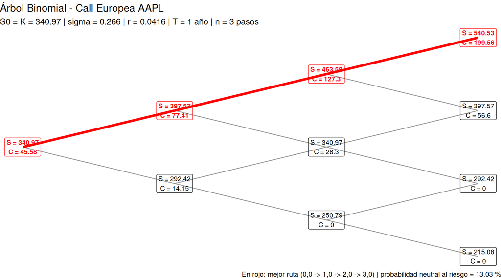

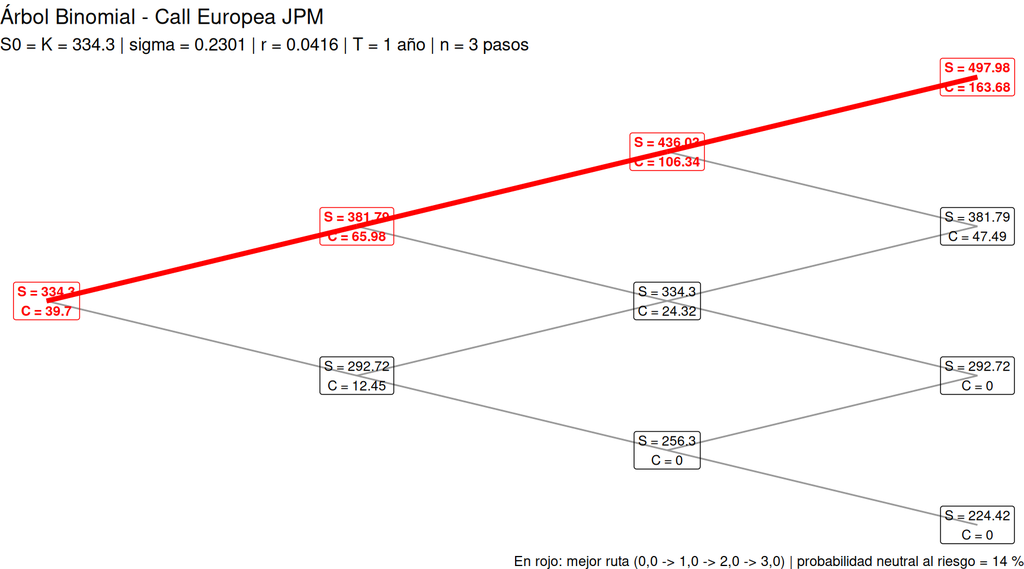

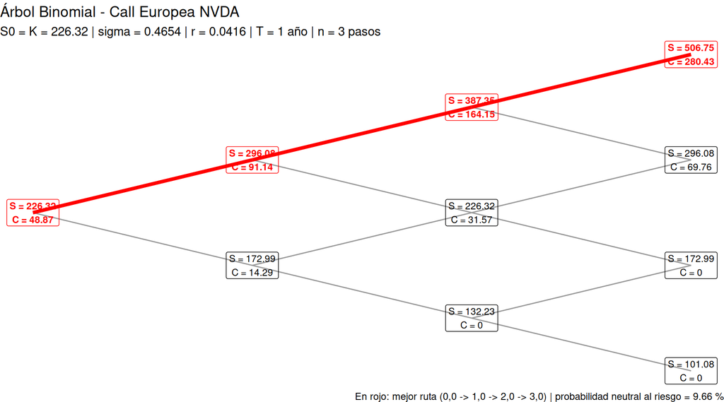

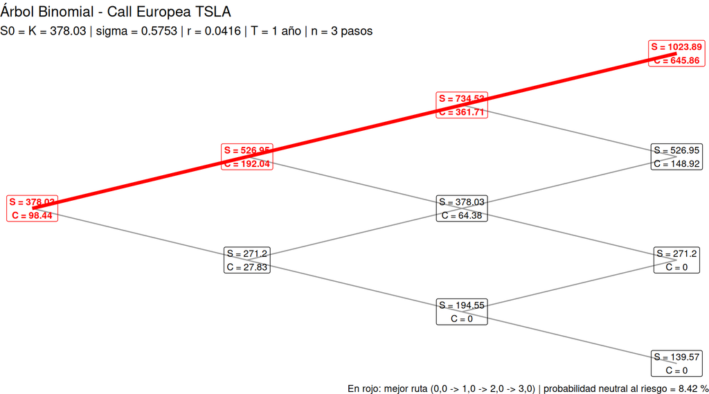

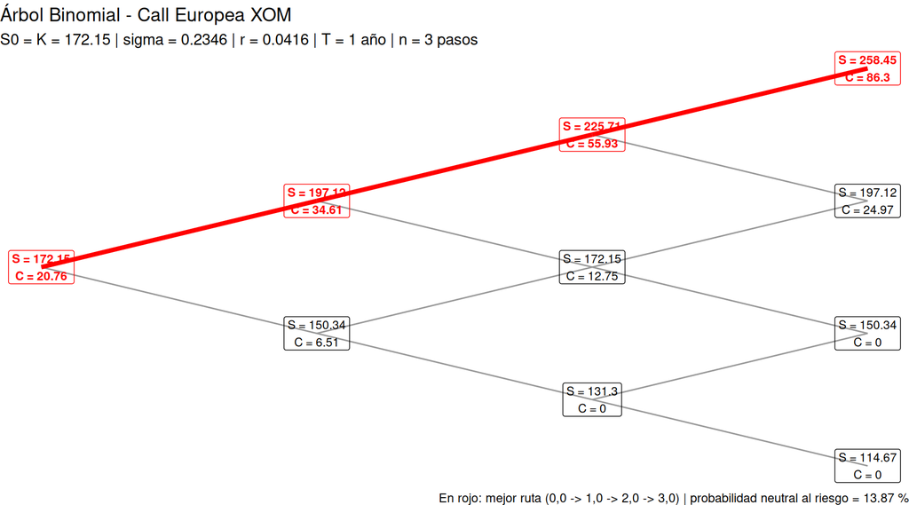

```r
T <- 1
n <- 3

# Construye los nodos del árbol, valúa la Call e identifica la mejor ruta
nodos_arbol <- function(activo, T = 1, n = 3) {
  S <- latest_prices[[activo]]
  K <- S
  sigma <- sigma_annual[[activo]]
  dt <- T / n
  u <- exp(sigma * sqrt(dt))
  d <- 1 / u
  p <- (exp(r * dt) - d) / (u - d)

  # Nodos: i = subidas, j = bajadas
  nodos <- expand.grid(i = 0:n, j = 0:n) %>%
    filter(i + j <= n) %>%
    mutate(Precio = S * u^i * d^j, name = paste(i, j, sep = ","), Call = NA_real_,
           x = i + j, y = i - j)

  # Valor de la Call: payoff al vencimiento e induccion hacia atras
  fin <- nodos$i + nodos$j == n
  nodos$Call[fin] <- pmax(nodos$Precio[fin] - K, 0)
  for (k in (n - 1):0) {
    for (idx in which(nodos$i + nodos$j == k)) {
      up <- which(nodos$i == nodos$i[idx] + 1 & nodos$j == nodos$j[idx])
      dn <- which(nodos$i == nodos$i[idx] & nodos$j == nodos$j[idx] + 1)
      nodos$Call[idx] <- exp(-r * dt) * (p * nodos$Call[up] + (1 - p) * nodos$Call[dn])
    }
  }

  # Mejor ruta: desde el nodo inicial se avanza siempre al nodo hijo con mayor
  # valor de la Call (para una Call es la trayectoria de maximo payoff)
  actual <- which(nodos$name == "0,0")
  ruta <- nodos$name[actual]
  for (k in 1:n) {
    up <- which(nodos$i == nodos$i[actual] + 1 & nodos$j == nodos$j[actual])
    dn <- which(nodos$i == nodos$i[actual] & nodos$j == nodos$j[actual] + 1)
    actual <- if (nodos$Call[up] >= nodos$Call[dn]) up else dn
    ruta <- c(ruta, nodos$name[actual])
  }
  nodos$Ruta <- ifelse(nodos$name %in% ruta, "Mejor ruta", "Otra")

  list(nodos = nodos, ruta = ruta, S = S, K = K, sigma = sigma,
       dt = dt, u = u, d = d, p = p)
}

arbol_binomial <- function(activo, T = 1, n = 3) {
  a <- nodos_arbol(activo, T, n)
  nodos <- a$nodos

  edges <- nodos %>% filter(i + j < n)
  edges_df <- bind_rows(
    data.frame(from = edges$name, to = paste(edges$i + 1, edges$j, sep = ",")),
    data.frame(from = edges$name, to = paste(edges$i, edges$j + 1, sep = ","))
  )
  tramos_ruta <- paste(head(a$ruta, -1), tail(a$ruta, -1))
  edges_df$Ruta <- ifelse(paste(edges_df$from, edges_df$to) %in% tramos_ruta, "Mejor ruta", "Otra")

  vertices_df <- nodos %>% select(name, Precio, Call, x, y, Ruta)
  graph <- graph_from_data_frame(d = edges_df, vertices = vertices_df, directed = TRUE)

  ggraph(graph, layout = "manual", x = vertices_df$x, y = vertices_df$y) +
    geom_edge_link(aes(filter = Ruta == "Otra"), colour = "grey60") +
    geom_edge_link(aes(filter = Ruta == "Mejor ruta"), colour = "red", edge_width = 1.5) +
    geom_node_label(aes(filter = Ruta == "Otra",
                        label = paste0("S = ", round(Precio, 2), "\nC = ", round(Call, 2))),
                    size = 3) +
    geom_node_label(aes(filter = Ruta == "Mejor ruta",
                        label = paste0("S = ", round(Precio, 2), "\nC = ", round(Call, 2))),
                    size = 3, colour = "red", fontface = "bold") +
    labs(title = paste("Árbol Binomial - Call Europea", activo),
         subtitle = paste0("S0 = K = ", round(a$S, 2), " | sigma = ", round(a$sigma, 4),
                           " | r = ", r, " | T = ", T, " año | n = ", n, " pasos"),
         caption = paste0("En rojo: mejor ruta (", paste(a$ruta, collapse = " -> "),
                          ") | probabilidad neutral al riesgo = ", round(a$p^n * 100, 2), " %")) +
    theme_void()
}

for (activo in tick) print(arbol_binomial(activo, T, n))
```

**Interpretación:** Para cada acción del portafolio se construye un árbol binomial de 3 pasos (T = 1 año) con strike igual al precio actual (ATM). Cada nodo muestra el precio del subyacente (S) y el valor de la Call europea (C) calculado por inducción hacia atrás; con T = 1 el valor del nodo inicial es menor al de la sección 8, que usa T = 2. La **ruta en rojo** marca la mejor trayectoria para el comprador de la Call: en cada paso se elige el nodo con mayor valor de la opción, lo que lleva a tres subidas consecutivas y al payoff máximo.

# 11. Cobertura financiera y distribución entre activos

```r
cobertura_pct <- 0.85
cobertura_monto <- cobertura_pct * investment
cobertura_dist <- cobertura_monto * weights_media
names(cobertura_dist) <- tick
cobertura_dist
```

```
##       AAPL        JPM       NVDA       TSLA        XOM
## 213071.281 285760.006  52522.899   8071.616 290574.197
```

**Interpretación:** Se define una estrategia de cobertura trimestral del 85% del portafolio, distribuida según los pesos óptimos en acciones.

# Justificación final

Se desarrolló una estrategia de inversión diversificada usando media-varianza, simulación de precios mediante MGB y análisis de riesgo con VaR. La cobertura se evaluó con opciones Call Europeas valuadas con árboles binomiales y rolling trimestral, y se definió un porcentaje fijo de cobertura con distribución proporcional. En la práctica (secciones 12.1 y 13) se compraron en Investopedia Calls americanas de 52 días sobre cada acción para participar en las subidas con pérdida acotada, y en CME un Put sobre el Micro E-mini Nasdaq-100 como protección del portafolio contra caídas. Esta metodología permite gestionar de forma activa el riesgo y proyectar el valor del portafolio con fundamentos sólidos.

## ¿Cómo se divide el dinero para la cobertura de las opciones?

El monto destinado a la cobertura se calculó como el 85% del total del portafolio. Luego, este valor se distribuyó entre las acciones del portafolio en proporción a los pesos de mínima varianza asignados a cada activo. Esto asegura que la cobertura sea coherente con la estructura del portafolio base.

# 12. Análisis de los resultados de los árboles binomiales

```r
resumen_arboles <- map_dfr(tick, function(activo) {
  a <- nodos_arbol(activo, T, n)
  fin <- a$nodos[a$nodos$i + a$nodos$j == n, ]
  nodo_final <- a$nodos[a$nodos$name == tail(a$ruta, 1), ]
  call0 <- a$nodos$Call[a$nodos$name == "0,0"]
  tibble(
    Accion = activo,
    S0 = a$S,
    sigma = a$sigma,
    u = a$u,
    d = a$d,
    p = a$p,
    Call_0 = call0,
    Call_pct_S0 = 100 * call0 / a$S,
    S_final_mejor = nodo_final$Precio,
    Payoff_mejor = nodo_final$Call,
    Multiplo = nodo_final$Call / call0,
    Prob_mejor_ruta = 100 * a$p^n,
    Prob_ejercicio = 100 * sum(dbinom(fin$i, n, a$p)[fin$Call > 0])
  )
})

# Costo de cubrir con Calls ATM el monto de cobertura (85 %) de cada acción
resumen_arboles <- resumen_arboles %>%
  mutate(Monto_cobertura = cobertura_dist[Accion],
         Num_opciones = Monto_cobertura / S0,
         Costo_primas = Num_opciones * Call_0)

resumen_arboles %>%
  mutate(across(where(is.numeric), ~ round(.x, 4))) %>%
  kable(caption = "Resumen de los árboles binomiales (T = 1 año, n = 3 pasos, K = S0)",
        col.names = c("Acción", "S0", "Sigma", "u", "d", "p", "Call (C0)", "C0 / S0 (%)",
                      "S final mejor ruta", "Payoff mejor ruta", "Payoff / C0 (veces)",
                      "Prob. mejor ruta (%)", "Prob. ejercicio (%)",
                      "Monto cobertura (USD)", "Núm. opciones", "Costo primas (USD)")) %>%
  kable_styling() %>%
  scroll_box(width = "100%")
```

Resumen de los árboles binomiales (T = 1 año, n = 3 pasos, K = S0)

| Acción | S0 | Sigma | u | d | p | Call (C0) | C0 / S0 (%) | S final mejor ruta | Payoff mejor ruta | Payoff / C0 (veces) | Prob. mejor ruta (%) | Prob. ejercicio (%) | Monto cobertura (USD) | Núm. opciones | Costo primas (USD) |
| --- | --- | --- | --- | --- | --- | --- | --- | --- | --- | --- | --- | --- | --- | --- | --- |
| AAPL | 340.97 | 0.2660 | 1.1660 | 0.8576 | 0.5070 | 45.5831 | 13.3686 | 540.5347 | 199.5647 | 4.3780 | 13.0291 | 51.0435 | 213071.281 | 624.8974 | 28484.738 |
| JPM | 334.30 | 0.2301 | 1.1421 | 0.8756 | 0.5192 | 39.6953 | 11.8742 | 497.9769 | 163.6769 | 4.1233 | 13.9994 | 52.8849 | 285760.006 | 854.8011 | 33931.615 |
| NVDA | 226.32 | 0.4654 | 1.3082 | 0.7644 | 0.4589 | 48.8733 | 21.5948 | 506.7470 | 280.4270 | 5.7378 | 9.6642 | 43.8494 | 52522.899 | 232.0736 | 11342.205 |
| TSLA | 378.03 | 0.5753 | 1.3939 | 0.7174 | 0.4384 | 98.4397 | 26.0402 | 1023.8930 | 645.8630 | 6.5610 | 8.4236 | 40.8010 | 8071.616 | 21.3518 | 2101.863 |
| XOM | 172.15 | 0.2346 | 1.1450 | 0.8733 | 0.5176 | 20.7645 | 12.0619 | 258.4495 | 86.2995 | 4.1561 | 13.8653 | 52.6358 | 290574.197 | 1687.9129 | 35048.735 |

```r
# Valores de apoyo para el texto
mas_vol   <- resumen_arboles$Accion[which.max(resumen_arboles$sigma)]
menos_vol <- resumen_arboles$Accion[which.min(resumen_arboles$sigma)]
mas_cara  <- resumen_arboles$Accion[which.max(resumen_arboles$Call_pct_S0)]
mas_barata <- resumen_arboles$Accion[which.min(resumen_arboles$Call_pct_S0)]
costo_total <- sum(resumen_arboles$Costo_primas)
f2 <- function(x) format(round(x, 2), nsmall = 2, big.mark = ",")
```

**¿Qué muestra la ruta en rojo?** En cada árbol la ruta roja parte del nodo inicial y, en cada paso, avanza al nodo hijo con mayor valor de la Call. Para una Call europea esa trayectoria siempre es la de **tres subidas consecutivas** (0,0 → 1,0 → 2,0 → 3,0): es el escenario en el que el precio de la acción termina más alto, la opción queda más *in the money* y el payoff al vencimiento es máximo. Es, por lo tanto, el **mejor escenario para quien compra la Call** (y el peor para quien la vende).

**1. La volatilidad determina el tamaño del árbol y el precio de la opción.** Los factores `u` y `d` dependen solo de la volatilidad anual: entre más volátil es la acción, más se abren las ramas del árbol y más vale la opción. TSLA es la acción más volátil (sigma = 0.58) y JPM la menos volátil (sigma = 0.23). Por eso la Call ATM más cara en proporción a su precio es la de TSLA (26.04 % de S0) y la más barata es la de JPM (11.87 % de S0). Cubrir o apostar al alza en una acción volátil cuesta más prima.

**2. La mejor ruta es un escenario optimista, no el esperado.** La probabilidad neutral al riesgo de subir en cada paso (`p`) va de 0.44 a 0.52, por lo que la probabilidad de recorrer la ruta roja completa (p³) es de apenas 8.42 % a 14.00 %. Es decir, la ruta roja indica el **potencial máximo** de la opción, pero en la mayoría de los escenarios el precio final estará en nodos intermedios. La probabilidad de que la Call termine con algún valor (ejercicio) está entre 40.80 % y 52.88 %, porque con K = S0 solo pagan los nodos finales con más subidas que bajadas.

**3. Apalancamiento de la opción.** Si se cumple la mejor ruta, el payoff equivale a entre 4.12 y 6.56 veces la prima pagada. Esto muestra el efecto palanca de las opciones: con una inversión pequeña (la prima) se captura buena parte de la subida de la acción. A cambio, en las rutas bajistas la Call vence sin valor y se pierde el 100 % de la prima, aunque la pérdida queda **limitada** a ese monto.

**4. Costo de la estrategia de cobertura.** Si el 85 % del portafolio (USD 850,000.00) se cubriera comprando Calls ATM a un año de acuerdo con los pesos de mínima varianza, el costo total en primas sería de aproximadamente **USD 110,909.16** (11.09 % del capital invertido). Este es el “seguro” que se paga para participar en las subidas del mercado con pérdida acotada.

**5. Lectura para la toma de decisiones.** Las acciones con mayor volatilidad (por ejemplo TSLA) ofrecen la mejor ruta más rentable en términos absolutos, pero también tienen primas más caras y mayor dispersión de resultados; las de menor volatilidad (JPM) generan árboles más estrechos, primas más baratas y resultados más predecibles. Una Call protege contra el riesgo de **no participar** en una subida (o de una posición corta); para proteger el portafolio largo contra caídas, el instrumento natural sería una Put, cuya mejor ruta en el árbol sería la de tres bajadas consecutivas.

**Limitaciones.** El árbol usa solo 3 pasos, una volatilidad histórica constante y no considera dividendos (relevantes para JPM y XOM). Con más pasos el valor de la opción converge al de Black-Scholes y la probabilidad de cada ruta individual se vuelve todavía más pequeña.

# 12.1 Árboles binomiales de 1 y 2 pasos: Calls americanas operadas (vencimiento 18-dic-2026)

> Esta sección valúa exactamente las opciones que se compraron en el simulador de Investopedia el 27-oct-2026 (sección 13.3): **Calls americanas con vencimiento 18-dic-2026 (52 días, T ≈ 0.14 años)**, que cae dentro del rango de 1–3 meses de la actividad. Se usan los strikes de las estrategias (sección 13.1), el precio de la acción al momento de la operación, la volatilidad histórica anual de la sección 6, r = 4.16 % y el rendimiento por dividendo de TradingView (relevante para el ejercicio anticipado de una opción americana).

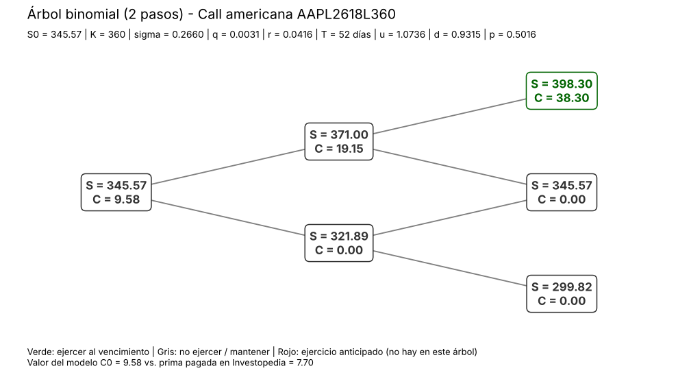

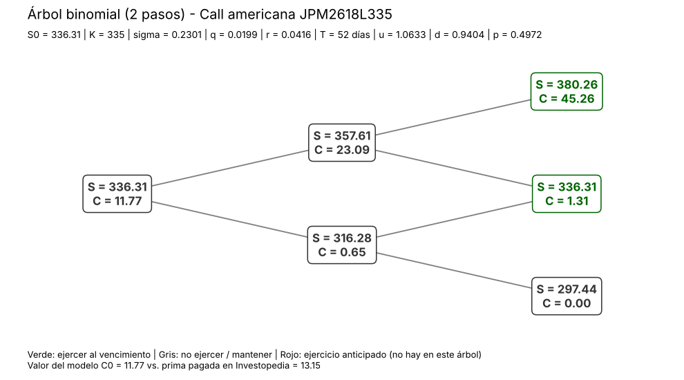

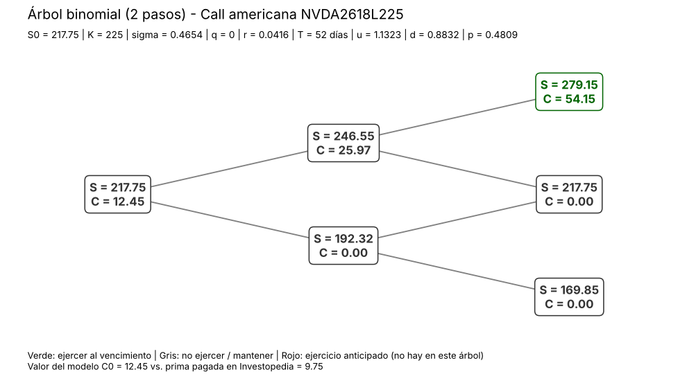

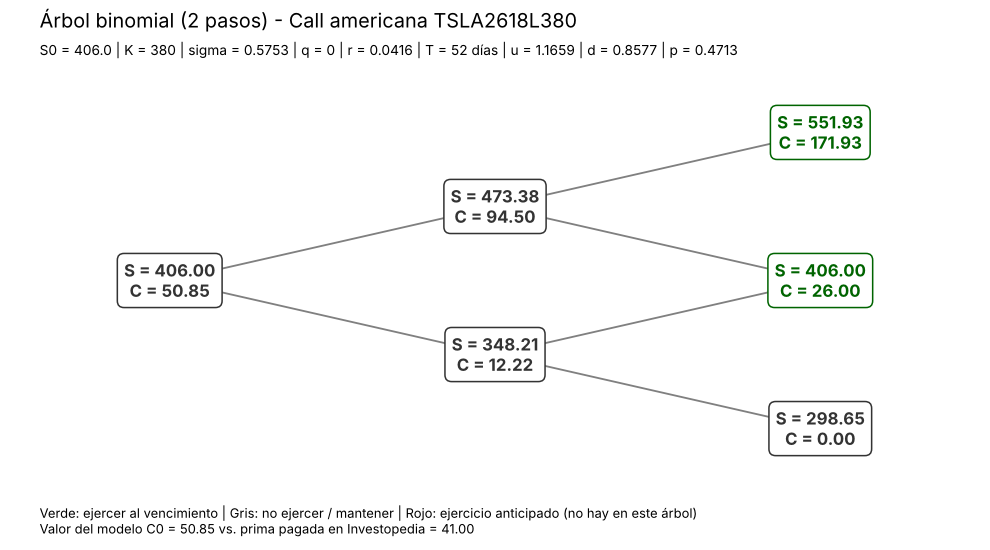

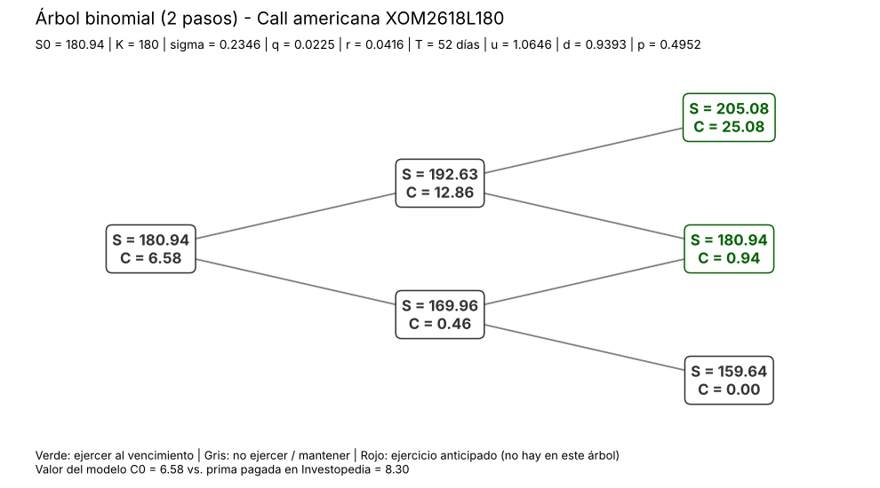

```r
fecha_op  <- as.Date("2026-10-27")
fecha_vto <- as.Date("2026-12-18")
T_am <- as.numeric(fecha_vto - fecha_op) / 365   # 52 días

# Operaciones en Investopedia (precio de la acción y prima pagada al ejecutar)
ops_am <- tibble(
  Accion = tick,
  S0     = c(345.57, 336.31, 217.75, 406.00, 180.94),  # precio de ejecución de la acción
  K      = c(360, 335, 225, 380, 180),
  q      = c(0.0031, 0.0199, 0, 0, 0.0225),     # rendimiento por dividendo (TradingView)
  Prima_mercado = c(7.70, 13.15, 9.75, 41.00, 8.30),  # prima de ejecución por opción
  Contrato = c("AAPL2618L360", "JPM2618L335", "NVDA2618L225", "TSLA2618L380", "XOM2618L180")
) %>%
  mutate(sigma = sigma_annual[Accion])

# Árbol de una Call americana con dividendo continuo q: compara en cada nodo
# el valor de mantener (inducción hacia atrás) contra el ejercicio inmediato
arbol_americana <- function(S, K, sigma, T, n, q = 0) {
  dt <- T / n
  u <- exp(sigma * sqrt(dt)); d <- 1 / u
  p <- (exp((r - q) * dt) - d) / (u - d)
  nodos <- expand.grid(i = 0:n, j = 0:n) %>%
    filter(i + j <= n) %>%
    mutate(Precio = S * u^i * d^j, name = paste(i, j, sep = ","),
           Intrinseco = pmax(Precio - K, 0), Call = NA_real_, Ejercer = FALSE,
           x = i + j, y = i - j)
  fin <- nodos$i + nodos$j == n
  nodos$Call[fin] <- nodos$Intrinseco[fin]
  nodos$Ejercer[fin] <- nodos$Intrinseco[fin] > 0
  for (k in (n - 1):0) {
    for (idx in which(nodos$i + nodos$j == k)) {
      up <- which(nodos$i == nodos$i[idx] + 1 & nodos$j == nodos$j[idx])
      dn <- which(nodos$i == nodos$i[idx] & nodos$j == nodos$j[idx] + 1)
      mantener <- exp(-r * dt) * (p * nodos$Call[up] + (1 - p) * nodos$Call[dn])
      nodos$Ejercer[idx] <- nodos$Intrinseco[idx] > mantener
      nodos$Call[idx] <- max(mantener, nodos$Intrinseco[idx])
    }
  }
  list(nodos = nodos, u = u, d = d, p = p, dt = dt, C0 = nodos$Call[nodos$name == "0,0"])
}

grafica_americana <- function(fila, n = 2) {
  a <- arbol_americana(fila$S0, fila$K, fila$sigma, T_am, n, fila$q)
  nodos <- a$nodos %>%
    mutate(Estado = case_when(i + j < n & Ejercer ~ "Ejercicio anticipado",
                              i + j == n & Ejercer ~ "Ejercer al vencimiento",
                              TRUE ~ "No ejercer / mantener"),
           Estado = factor(Estado, levels = c("Ejercicio anticipado", "Ejercer al vencimiento",
                                              "No ejercer / mantener")))
  edges <- nodos %>% filter(i + j < n)
  edges_df <- bind_rows(
    data.frame(from = edges$name, to = paste(edges$i + 1, edges$j, sep = ",")),
    data.frame(from = edges$name, to = paste(edges$i, edges$j + 1, sep = ",")))
  vertices_df <- nodos %>% select(name, Precio, Call, Estado, x, y)
  g <- graph_from_data_frame(edges_df, vertices = vertices_df, directed = TRUE)
  ggraph(g, layout = "manual", x = vertices_df$x, y = vertices_df$y) +
    geom_edge_link(colour = "grey60") +
    geom_node_label(aes(label = paste0("S = ", round(Precio, 2), "\nC = ", round(Call, 2)),
                        colour = Estado), size = 3.4, fontface = "bold") +
    scale_colour_manual(values = c("Ejercicio anticipado" = "red",
                                   "Ejercer al vencimiento" = "darkgreen",
                                   "No ejercer / mantener" = "grey30"), drop = FALSE) +
    labs(title = paste0("Árbol binomial (", n, " pasos) - Call americana ", fila$Contrato),
         subtitle = paste0("S0 = ", fila$S0, " | K = ", fila$K, " | sigma = ", round(fila$sigma, 4),
                           " | q = ", fila$q, " | r = ", r, " | T = 52 días | u = ", round(a$u, 4),
                           " | d = ", round(a$d, 4), " | p = ", round(a$p, 4)),
         caption = paste0("Valor del modelo C0 = ", round(a$C0, 2),
                          " vs. prima pagada en Investopedia = ", fila$Prima_mercado),
         colour = NULL) +
    theme_void() + theme(legend.position = "bottom")
}

for (k in seq_len(nrow(ops_am))) print(grafica_americana(ops_am[k, ], n = 2))
```

```r
resumen_am <- ops_am %>%
  rowwise() %>%
  mutate(
    C_1paso  = arbol_americana(S0, K, sigma, T_am, 1, q)$C0,
    C_2pasos = arbol_americana(S0, K, sigma, T_am, 2, q)$C0,
    C_50pasos = arbol_americana(S0, K, sigma, T_am, 50, q)$C0,
    p_2 = arbol_americana(S0, K, sigma, T_am, 2, q)$p,
    Ej_anticipado_50 = {a50 <- arbol_americana(S0, K, sigma, T_am, 50, q)$nodos
                        sum(a50$Ejercer & a50$i + a50$j < 50)},
    Prob_ITM_2 = {a <- arbol_americana(S0, K, sigma, T_am, 2, q)
                  fin <- a$nodos[a$nodos$i + a$nodos$j == 2, ]
                  100 * sum(dbinom(fin$i, 2, a$p)[fin$Intrinseco > 0])},
    S_esperado = S0 * exp((r - q) * T_am),
    Breakeven = K + Prima_mercado,
    Subida_necesaria = 100 * (Breakeven / S0 - 1),
    Dif_modelo_mercado = C_2pasos - Prima_mercado
  ) %>%
  ungroup()

resumen_am %>%
  select(Contrato, S0, K, sigma, C_1paso, C_2pasos, C_50pasos, Prima_mercado,
         Dif_modelo_mercado, Prob_ITM_2, Ej_anticipado_50, S_esperado, Breakeven, Subida_necesaria) %>%
  mutate(across(where(is.numeric), ~ round(.x, 2))) %>%
  kable(caption = "Calls americanas operadas: árbol de 1 y 2 pasos vs. prima de mercado (vencimiento 18-dic-2026)",
        col.names = c("Contrato", "S0", "K", "Sigma", "C (1 paso)", "C (2 pasos)", "C (50 pasos)",
                      "Prima pagada", "Modelo - mercado", "Prob. ITM 2 pasos (%)", "Nodos ejercicio anticipado (50 pasos)",
                      "S esperado (neutral al riesgo)", "Punto de equilibrio", "Subida necesaria (%)")) %>%
  kable_styling() %>%
  scroll_box(width = "100%")
```

Calls americanas operadas: árbol de 1 y 2 pasos vs. prima de mercado (vencimiento 18-dic-2026)

| Contrato | S0 | K | Sigma | C (1 paso) | C (2 pasos) | C (50 pasos) | Prima pagada | Modelo - mercado | Prob. ITM 2 pasos (%) | Nodos ejercicio anticipado (50 pasos) | S esperado (neutral al riesgo) | Punto de equilibrio | Subida necesaria (%) |
| --- | --- | --- | --- | --- | --- | --- | --- | --- | --- | --- | --- | --- | --- |
| AAPL2618L360 | 345.57 | 360 | 0.27 | 11.02 | 9.58 | 8.78 | 7.7 | 1.88 | 25.16 | 0 | 347.47 | 367.7 | 6.4 |
| JPM2618L335 | 336.31 | 335 | 0.23 | 15.69 | 11.77 | 12.78 | 13.15 | -1.38 | 74.72 | 0 | 337.35 | 348.15 | 3.52 |
| NVDA2618L225 | 217.75 | 225 | 0.47 | 16.25 | 12.45 | 12.73 | 9.75 | 2.7 | 23.13 | 0 | 219.04 | 234.75 | 7.81 |
| TSLA2618L380 | 406 | 380 | 0.58 | 56.85 | 50.85 | 49.77 | 41 | 9.85 | 72.05 | 0 | 408.41 | 421 | 3.69 |
| XOM2618L180 | 180.94 | 180 | 0.23 | 8.68 | 6.58 | 7.09 | 8.3 | -1.72 | 74.52 | 1 | 181.43 | 188.3 | 4.07 |

**Interpretación de los árboles de 1–2 pasos.**

1. **Niveles de nodos.** Con 2 pasos de 26 días cada uno, el árbol tiene 3 nodos finales: dos subidas, una subida y una bajada, o dos bajadas. Como el horizonte es de solo 52 días, `u` y `d` quedan muy cerca de 1 (por ejemplo, u = 1.06 y d = 0.94 en JPM y XOM, y u = 1.17 y d = 0.86 en TSLA). El rango de precios posibles es mucho más estrecho que en los árboles de un año de la sección 10, y por eso las primas son menores.
2. **Ejercicio anticipado.** En los árboles de 2 pasos **ningún nodo intermedio recomienda ejercer antes del vencimiento**: el valor de mantener la Call siempre supera su valor intrínseco. Por eso, con 2 pasos, la Call americana vale lo mismo que la europea. Solo al refinar el árbol a 50 pasos aparece un nodo de ejercicio anticipado en **XOM**, la acción con mayor dividendo (2.25 %). Esto confirma que el dividendo es lo único que puede hacer conveniente ejercer una Call americana antes de tiempo, y solo cuando está muy *in the money*.
3. **Modelo vs. mercado.** Con 1 paso el árbol es muy burdo: en las cinco acciones da un valor mayor que el de 50 pasos. Con 2 pasos ya se acerca al valor de convergencia. Contra la prima pagada en Investopedia hay dos grupos:
   - **AAPL, NVDA y TSLA:** el modelo da un valor **mayor** que el mercado (+1.88, +2.70 y +9.85 USD por opción).
   - **JPM y XOM:** el modelo da un valor **menor** (−1.38 y −1.72 USD).

   La diferencia viene de la volatilidad. El árbol usa la **volatilidad histórica** de 3 años, y el mercado cotiza con la **volatilidad implícita**. En NVDA y TSLA la volatilidad histórica (46.5 % y 57.5 %) es mayor que la que hoy descuenta el mercado, así que, según el modelo, esas opciones se compraron “baratas”. En JPM y XOM el mercado descuenta más volatilidad que la histórica, posiblemente por la corrección reciente de JPM y el rally de XOM en octubre.
4. **Forecast y punto de equilibrio.** El precio esperado neutral al riesgo al vencimiento apenas supera a S0, porque solo crece a la tasa r − q durante 52 días. Para ganar al vencimiento, la acción tiene que superar K + prima:

   | Acción | Subida necesaria | Situación |
   | --- | --- | --- |
   | JPM | 3.5 % | casi *at the money* |
   | TSLA | 3.7 % | *in the money* (S0 = 406 > K = 380) |
   | XOM | 4.1 % | casi *at the money* |
   | AAPL | 6.4 % | *out of the money* |
   | NVDA | 7.8 % | *out of the money* |

   Con 2 pasos, la probabilidad neutral al riesgo de terminar *in the money* es de alrededor de 72–75 % para JPM, TSLA y XOM, y de solo 23–25 % para AAPL y NVDA.

# 13. Evidencia de mercado: TradingView, CME e Investopedia

> Las capturas están incrustadas directamente en este documento (base64), por lo que no es necesario tener archivos de imagen en la misma carpeta para compilar el Rmd. Precios de TradingView al cierre del 23-oct-2026.

## 13.1 TradingView: gráficas con strikes y estadísticas clave

En cada gráfica se trazan como líneas horizontales los **strikes de las estrategias** de opciones del portafolio y se compara el rendimiento de la acción contra el **S&P 500 (SPX)** desde mayo de 2026. Las estadísticas clave (capitalización, P/U, UPA, dividendos y beta) complementan los parámetros de los árboles binomiales: la beta indica la sensibilidad al mercado y el rendimiento por dividendo es relevante para valuar opciones americanas (ejercicio anticipado).

### AAPL — Apple Inc.

[figure not shown]

AAPL - TradingView (strikes 305, 325, 360 y 375)

[figure not shown]

AAPL - Key stats

**Interpretación:** AAPL cerró en **USD 347.73** con un rendimiento de **+26.42 %** en el periodo, muy por encima del SPX (+7.25 %). El precio está entre los strikes de 325 y 360: los niveles de 305 y 325 quedan como soporte (*in the money* para Calls, protección para Puts) y los de 360–375 como objetivos de alza. Capitalización de USD 5.07 T, P/U de 39.92, beta (1Y) de 0.71 y dividendo de 0.31 %, por lo que el ejercicio anticipado de una Call americana es poco relevante.

### JPM — JPMorgan Chase & Co.

[figure not shown]

JPM - TradingView (strike 335)

[figure not shown]

JPM - Key stats

**Interpretación:** JPM cerró en **USD 331.58** (−1.47 % en el día) con un rendimiento de **+6.67 %**, ligeramente por debajo del SPX (+7.24 %), tras corregir desde máximos de agosto. El precio está muy cerca del strike de **335** (prácticamente *at the money*), por lo que las opciones de ese strike tienen el mayor valor temporal y la delta más cercana a 0.5. P/U de 14.12, beta de 0.54 y dividendo de 1.99 %: el dividendo hace relevante evaluar el ejercicio anticipado en opciones americanas.

### NVDA — NVIDIA Corporation

[figure not shown]

NVDA - TradingView (strikes 225 y 240)

[figure not shown]

NVDA - Key stats

**Interpretación:** NVDA cerró en **USD 210.96** con un rendimiento de **+4.37 %**, por debajo del SPX (+7.92 %), luego de caer desde un máximo de octubre cerca del strike de 240. Ambos strikes (225 y 240) quedan *out of the money* para Calls, lo que requiere una subida de 7 % a 14 % para entrar en dinero. Es la acción con mayor capitalización (USD 5.08 T) y una beta de 1.71, lo que confirma su alta volatilidad y primas más caras en el árbol binomial.

### TSLA — Tesla, Inc.

[figure not shown]

TSLA - TradingView (strike 380)

[figure not shown]

TSLA - Key stats

**Interpretación:** TSLA cerró en **USD 372.22** con un rendimiento de **−0.82 %**, la única acción del portafolio en negativo y muy por debajo del SPX (+7.25 %), con una caída fuerte en julio y recuperación posterior. El strike de **380** está apenas 2 % arriba del precio (casi *at the money*). Tiene la beta más alta (1.87), el P/U más elevado (412.03) y no paga dividendo, por lo que una Call americana se comporta igual que una europea.

### XOM — ExxonMobil

[figure not shown]

XOM - TradingView (strikes 165 y 180)

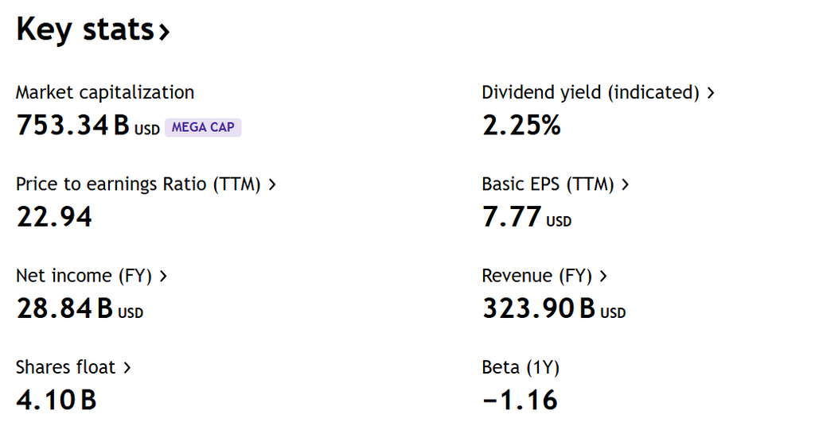

XOM - Key stats

**Interpretación:** XOM cerró en **USD 183.21** (+2.79 % en el día) con un rendimiento de **+22.26 %**, con un rally fuerte en octubre. Ya superó ambos strikes (165 y 180), por lo que las Calls de esos strikes están *in the money*. Es la acción con mayor dividendo (2.25 %) y beta (1Y) negativa (−1.16), lo que la convierte en el diversificador del portafolio frente al mercado y hace relevante el ejercicio anticipado en opciones americanas.

## 13.2 CME Group: operación y asignación

Como CME no lista opciones sobre acciones individuales, la cobertura del portafolio se realizó con **opciones sobre el futuro Micro E-mini Nasdaq-100 (MNQ, vencimiento diciembre 2026)**, índice en el que AAPL, NVDA y TSLA tienen un peso importante.

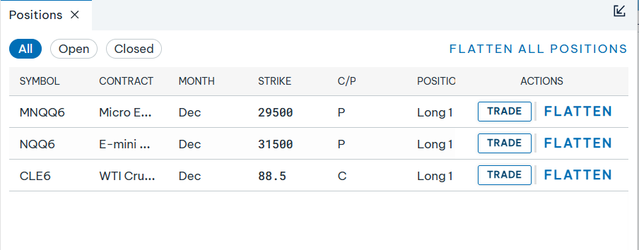

CME Group Simulator - Posiciones

| Concepto | Detalle |
| --- | --- |
| Fecha de operación | 26-oct-2026 |
| Instrumento | Put sobre futuro Micro E-mini Nasdaq-100 (MNQZ6), vencimiento 18-dic-2026 (~53 días) |
| Operación | Compra (Long) de 1 Put |
| Strike | 29,500 (futuro en ~29,420: ligeramente *in the money*) |
| Orden | Límite a 1,063, día (DAY) |
| Precio de ejecución | 1,051 puntos |
| Multiplicador | USD 2 por punto |
| Prima pagada | 1,051 × 2 = **USD 2,102** |

**Interpretación:** La compra del Put funciona como **seguro contra una caída del Nasdaq-100** antes de diciembre: si el futuro cae por debajo de 29,500, el Put gana valor y compensa parte de la pérdida de AAPL, NVDA y TSLA; si el mercado sube, la pérdida máxima es la prima pagada (USD 2,102). El punto de equilibrio al vencimiento es 29,500 − 1,051 = **28,449** puntos (≈ 3.3 % abajo del nivel actual). El vencimiento de ~53 días cae dentro del rango de 1–3 meses de la actividad. Las otras posiciones de la cuenta de práctica (NQQ6 y CLE6) corresponden a operaciones distintas a esta estrategia.

## 13.3 Investopedia Stock Simulator: operación y asignación

En la liga **“Derivados y Riesgos EGADE 26”** del simulador de Investopedia, el 27-oct-2026 se armó el portafolio de mínima varianza y se compró una **Call americana** por acción. Las Calls tienen vencimiento el 18-dic-2026 (52 días) y los strikes de las estrategias de la sección 13.1. Se usó el mismo vencimiento que el Put de CME (sección 13.2) para que las dos coberturas se evalúen en el mismo horizonte.

### Asignación del capital en acciones

Los pesos de mínima varianza (sección 4) se aplicaron sobre USD 950,000, no sobre el millón completo, para dejar efectivo para las primas. La cuenta ya tenía 100 acciones de AAPL compradas el 25-sep-2026, por lo que solo se compraron 588 más.

| Acción | Peso objetivo | Acciones compradas | Posición final | Precio de ejecución | Costo total (USD) | Peso real |
| --- | --- | --- | --- | --- | --- | --- |
| AAPL | 25.07 % | 588 (+100 previas) | 688 | 345.57 | 236,952.22 | 24.97 % |
| JPM | 33.62 % | 950 | 950 | 336.31 | 319,494.50 | 33.67 % |
| NVDA | 6.18 % | 269 | 269 | 217.75 | 58,574.67 | 6.17 % |
| TSLA | 0.95 % | 22 | 22 | 406.00 | 8,932.00 | 0.94 % |
| XOM | 34.19 % | 1,796 | 1,796 | 180.94 | 324,968.24 | 34.25 % |
| **Total** | **100 %** |  |  |  | **948,921.63** | **100 %** |

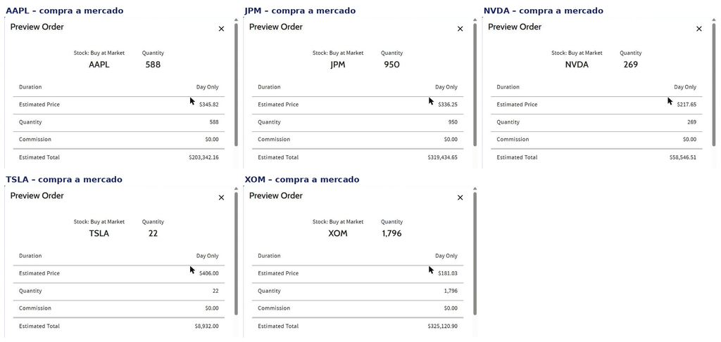

Investopedia - Vista previa de las órdenes de compra de acciones

### Compra de las Calls americanas (vencimiento 18-dic-2026)

| Contrato | Acción | Strike | Situación al comprar | Prima | Costo (1 contrato = 100 opciones) | Acciones cubiertas / acciones en cartera |
| --- | --- | --- | --- | --- | --- | --- |
| AAPL2618L360 | AAPL | 360 | *Out of the money* | 7.70 | 770.00 | 100 / 688 |
| JPM2618L335 | JPM | 335 | ~*At the money* | 13.15 | 1,315.00 | 100 / 950 |
| NVDA2618L225 | NVDA | 225 | *Out of the money* | 9.75 | 975.00 | 100 / 269 |
| TSLA2618L380 | TSLA | 380 | *In the money* | 41.00 | 4,100.00 | 100 / 22 |
| XOM2618L180 | XOM | 180 | ~*At the money* | 8.30 | 830.00 | 100 / 1,796 |
| **Total** |  |  |  |  | **7,990.00** |  |

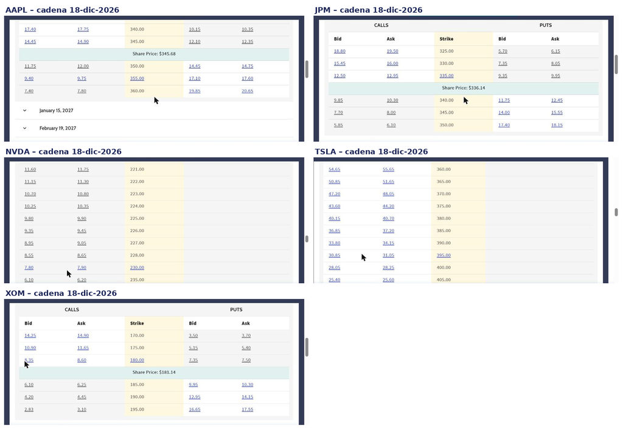

Investopedia - Cadenas de opciones con vencimiento 18-dic-2026 (strikes operados)

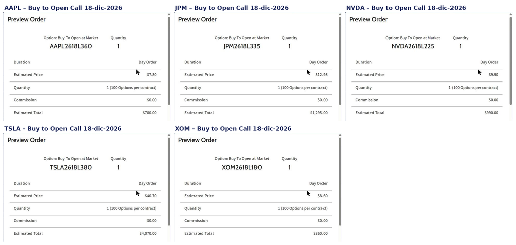

Investopedia - Vista previa de las órdenes Buy to Open de las Calls

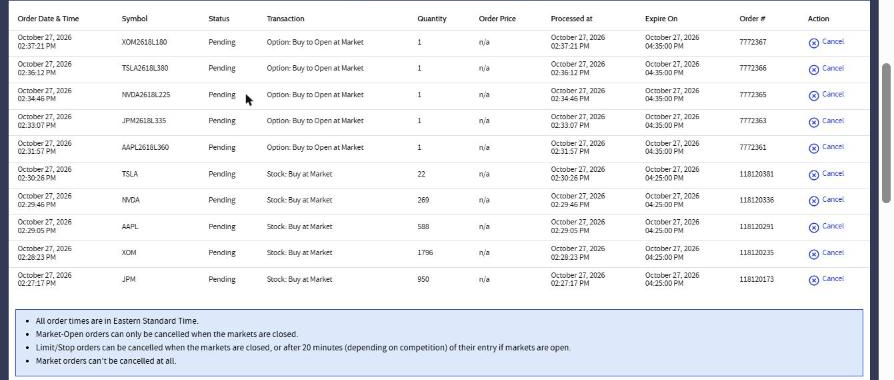

Investopedia - Órdenes enviadas en estado pendiente (el simulador las ejecuta con retraso)

### Portafolio final e historial de operaciones

[figure not shown]

Investopedia - Resumen de la cuenta y tenencias de acciones y opciones

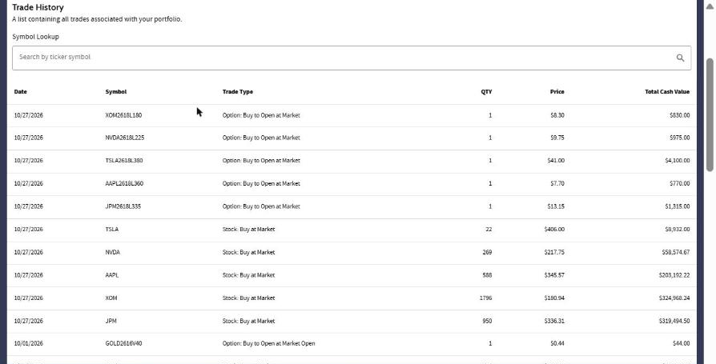

Investopedia - Historial de operaciones (Trade History)

> En la pestaña *Options* el simulador no muestra el símbolo del contrato. Las filas siguen el orden AAPL, JPM, NVDA, TSLA y XOM, y coinciden con las primas del historial de operaciones.

**Interpretación:**

- **Asignación.** Los pesos reales de las acciones coinciden con los de mínima varianza (diferencias menores a 0.1 puntos). El portafolio quedó concentrado en **XOM (34 %) y JPM (34 %)**, las acciones de menor volatilidad (≈ 23 % anual), con XOM además casi sin correlación con el resto, y con un peso casi nulo en TSLA (0.9 %). Después de las compras, la cuenta conserva ≈ USD 42,300 en efectivo.
- **Costo de las Calls.** Las primas suman **USD 7,990, 0.8 % del capital**, mucho menos que el costo teórico de cubrir el 85 % del portafolio con Calls ATM a un año de la sección 12. Esto se debe a que solo se compró un contrato por acción y a que el vencimiento es de 52 días.
- **Función de las Calls.** Las Calls sobre acciones que ya se tienen **no protegen contra caídas**. Lo que hacen es aumentar la exposición al alza con pérdida máxima limitada a la prima, y funcionan como cobertura del riesgo de no participar en una subida. La protección del portafolio largo contra una baja es el **Put sobre el Micro E-mini Nasdaq-100 comprado en CME** (sección 13.2). Las dos patas juntas forman la estrategia: Calls para el *upside* de cada acción y Put sobre índice para el *downside* del portafolio.
- **Proporción de cobertura.** Cada contrato equivale a 100 acciones. En **TSLA** el contrato representa 100 acciones contra solo 22 en cartera, así que la exposición a TSLA está **apalancada** (4.5 veces la posición) y depende sobre todo de la opción. En **XOM** el contrato cubre apenas 5.6 % de la posición. Para que la cobertura fuera proporcional a los pesos, habría que ajustar el número de contratos: más en JPM y XOM, ninguno o una fracción en TSLA.
- **Relación con los árboles binomiales.** Las primas pagadas son el insumo de la sección 12.1: el árbol de 2 pasos indica que las Calls de AAPL, NVDA y TSLA se compraron por debajo de su valor teórico con volatilidad histórica, y las de JPM y XOM por encima.